# Modelo de Risco de Crédito

Da análise exploratória à priorização financeira em lote

Credit Risk Analytics

2026-01-01

## O objetivo é priorizar risco sem substituir a política de crédito

### Decisão de negócio

Usar o score para priorizar propostas com maior probabilidade de inadimplência para revisão, tratamento de risco ou acompanhamento de carteira.

O modelo não aprova nem recusa crédito sozinho. Ele adiciona um sinal quantitativo, rastreável e mensurável ao processo.

1**Aplicações**Perfil financeiro, histórico e comportamento

2**Score**Probabilidade estimada de inadimplência

3**Ação**Priorizar análise e aplicar política

**Ponto de partida:** o desafio não é maximizar acurácia; é concentrar inadimplência nas propostas que receberão atenção adicional.

## Os testes de hipótese encontraram associações — não regras causais

### Evidência estatística

Para tipo de contrato, o qui-quadrado foi **293,15** com *p* < 0,001; o V de Cramér foi **0,0309**. Para gênero, qui-quadrado **920,01**, *p* < 0,001 e V de Cramér **0,0547**.

### Interpretação responsável

O grande volume torna *p*-values muito sensíveis. Os dois V de Cramér indicam associação **muito fraca**. Gênero é sinal de monitoramento e revisão de fairness, nunca uma regra isolada de decisão.

## A avaliação protegeu o teste final contra vazamento de informação

**Treino**Ajusta transformação e modelos*8,0729% de eventos*

**Validação**Escolhe parâmetros e threshold*8,0728% de eventos*

**Teste**Confirma o resultado final uma vez*8,0728% de eventos*

### Métodos aplicados

IV/WoE, KS univariado, qui-quadrado, V de Cramér, poda de correlação, remoção de constantes e validação cruzada estratificada.

### Por que isso importa

O conjunto de teste não escolheu hiperparâmetros nem threshold. Ele foi usado para confirmar o comportamento do modelo selecionado.

## A seleção reduziu complexidade sem deteriorar o PR-AUC

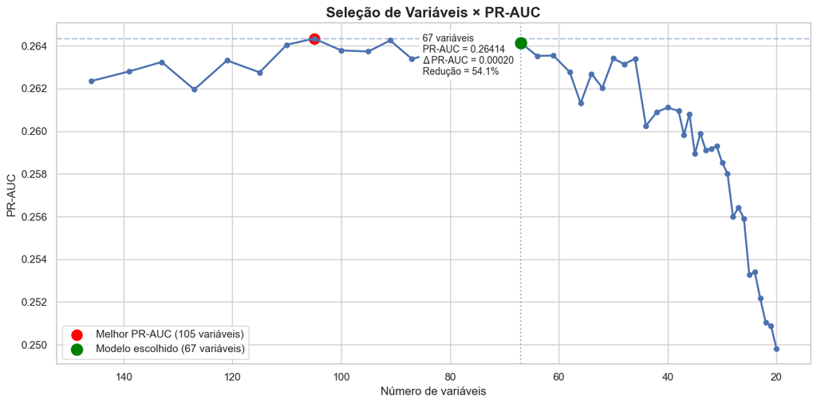

Evolução do PR-AUC durante a remoção iterativa de variáveis

### Decisão de engenharia

O processo removeu iterativamente as variáveis menos importantes e avaliou PR-AUC em validação cruzada a cada etapa.

O melhor ponto absoluto ocorreu com **105 variáveis** (PR-AUC **0,26434**). Foram escolhidas **67 variáveis**, com PR-AUC **0,26414** e desvio-padrão **0,00198**.

Isso reduz o contrato de entrada em **54,1%** sem perda material de poder preditivo.

## A calibração mostrou a limitação do baseline balanceado

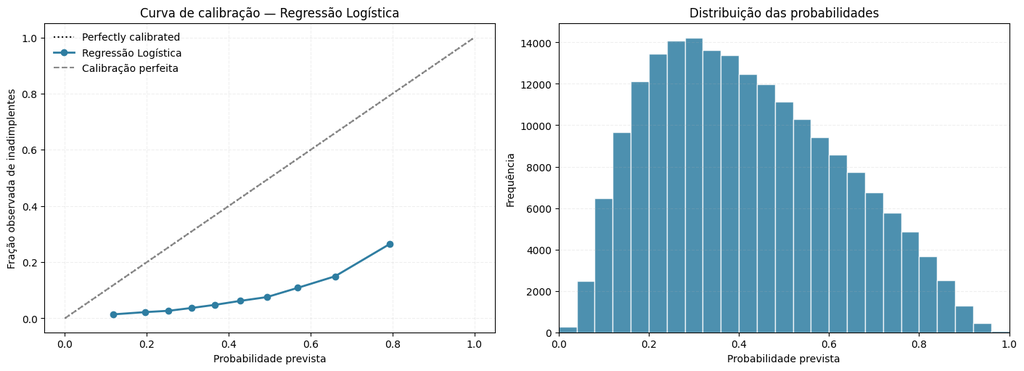

Curva de calibração e distribuição das probabilidades da Regressão Logística

### Resultado da análise

A curva fica abaixo da diagonal: a Regressão Logística com `class_weight="balanced"` superestima as probabilidades de inadimplência.

**Brier Score OOF: 0,20115**

Ela foi mantida como baseline de interpretação. Para ser usada como modelo probabilístico final, precisaria de uma etapa explícita de calibração.

## O campeão confirmou desempenho no teste final

**0,2789**PR-AUC no teste final

**0,7807**ROC-AUC

**0,4193**KS

**0,3313**F1-score

**0,6500**threshold

### Leitura operacional

No threshold definido na validação, os alertas atingiram precisão de **25,69%** e recall de **46,61%** no teste.

Em outras palavras, a taxa observada de inadimplência entre alertas foi aproximadamente **3,2 vezes** a taxa base da carteira (25,69% versus 8,07%).

## O modelo capturou R$ 1,17 bilhão de exposição inadimplente no teste

*R$ 1,61 biInadimplêncianão detectada Carteira analisada: R$ 36,77 bi. Exposição inadimplente total: R$ 2,78 bi. Valor capturado: 41,99%.* Falsos alertas representam exposição analisada, não perda realizada.

## A inferência será em lote, rastreável e controlada

[figure not shown]

DockerAirflowMLflowPostgreSQL

1**Carregar lote**CSV ou Parquet com validações

2**Resolver campeão**MLflow resolve o alias `@champion`

3**Predizer**Probabilidade e decisão pelo threshold

4**Salvar**Saída atômica e base para monitoramento

## O retreino preserva o campeão até existir evidência de melhora

[figure not shown]

DockerAirflowMLflowPostgreSQL

Dados rotulados  
novos desfechos

Treinar challenger  
treino e validação

Comparar no teste  
PR-AUC e guardrails

Melhorou?  
gate de promoção

Atualizar alias  
promove ou mantém campeão

O próximo amadurecimento é usar holdout temporal e gates adicionais: calibração, KS, recall mínimo, captura financeira, qualidade de dados e fairness review.

## Recomendação: operar o LightGBM como sinal governado de priorização

### Evidência apresentada

- EDA e testes de hipótese usados como análise de sinal e monitoramento
- Contrato enxuto de **67 variáveis**, 54,1% menor
- PR-AUC de **0,2789** no teste final
- **R$ 1,17 bilhão** de exposição inadimplente detectada no teste
- Inferência e retreino desenhados para rastreabilidade e promoção controlada

### Decisões de negócio pendentes

1. Definir ação para cada faixa de score
2. Definir capacidade de revisão e custo de falsos alertas
3. Acordar limites de drift e performance
4. Formalizar governança de promoção

O modelo está pronto para apoiar a priorização de risco em lote. O valor financeiro realizado dependerá da ação aplicada aos alertas e do acompanhamento dos desfechos após a implantação.

## Referências e limites de interpretação

| Tema | Evidência |
| --- | --- |
| Dados | Home Credit Default Risk, Kaggle; preparação no notebook 00. |
| EDA e testes | Notebook 01: IV/WoE, KS, qui-quadrado, V de Cramér, missingness e análise de outliers. |
| Seleção | Notebook 03: remoção iterativa com importância por permutação e PR-AUC em validação cruzada. |
| Avaliação | Teste separado; LightGBM campeão com PR-AUC 0,2789, ROC-AUC 0,7807 e KS 0,4193. |
| Financeiro | Avaliação no teste, com `AMT_CREDIT`; não equivale a perda ou economia realizada. |
| Operação | Airflow, MLflow, PostgreSQL e Docker; monitoramento preparado para Power BI. |